# Simulation Experiments

Andrea Brizzi

04/03/2021

## Settings

The objective of this html report is to document the results of each simulation. Here we define the settings of each simulation.

Time is measured in terms of weeks. Data is simulated according to a deterministic SEIR model. We assume the disease has mean exposure of 6 days and mean infectiousness of 14 days, implying an average generation time of 20 days (circa 3 weeks). Hidden inside the `simulate_data` function is an assumption about a constant 20% reporting fraction.

```r
gen_interval <- 3
simulations <- simulate_data(N=params$n_sims, gamma=1/6, sigma=1/14)
# In case we would like to simulate something that looks more like COVID, it would
# make more sense to take a look at daily incidence, and modify quite a few things.
```

We fit all different models assuming a gamma generation interval distribution with mean 20 days and standard deviation of 7.4 days.

```r
GTd <- R0::generation.time("gamma", c(20/7, 7.4/7))
```

## R estimates

In this experiment, I wanted to look at the effect of missed generations. To do so, I firstly simulate the data as in Megan’s paper, and then trim off them the data for 0, 1, 2 generation intervals. I fit the methods to each of these dataset and hopefully get some results later on.

```r
# list to store results from simulations
Sim_results <- list()

for(i in 1:3){

  # list for storage
  results_i <- list()

  for (gen in 0:params$missed_gens){
    # Missed generations parameter

    results_gen <- list()


  # for each of the 250 simulations
  for(j in 1:ncol(simulations$sims)){

    # data for fitting - simulation j with noise level i
    sim_ij <- data.frame(week=1:nrow(simulations[[i]]), cases=simulations[[i]][ ,j],
                         country=paste("sim", j, sep='_'))

    sim_ij_gen <- sim_ij %>% filter(week > gen_interval * gen)


    # fit & store results
    results_gen[[j]] <- fit_R0_seq(data=sim_ij_gen,
                        mean_GT=20/7, sd_GT=7.4/7, GTd=GTd, GT_week=3,
                        methods = params$methods)

    }

    #store results from each missed_gen cut off
    results_i[[gen + 1]] <- results_gen

  }

  # store results from each noise level
  Sim_results[[i]] <- results_i
}
```

At the moment I cannot seem to have EG_MLE working. WHY?

## Results

It is now time to compare results across the three different noise levels.

### No Noise

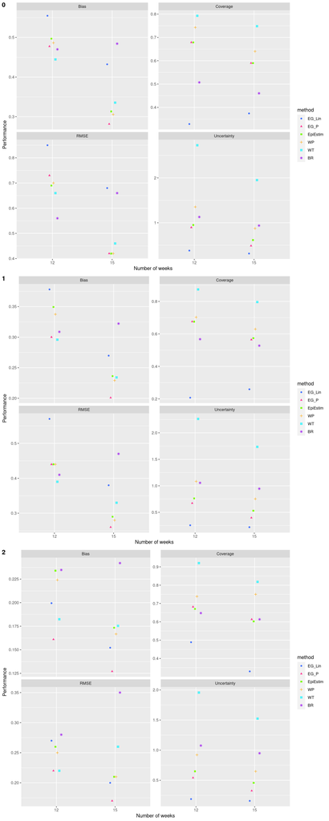

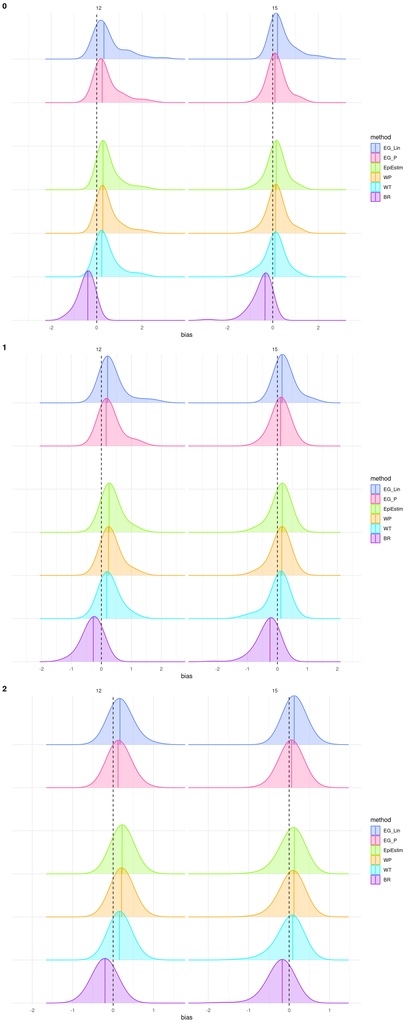

### Poisson Noise

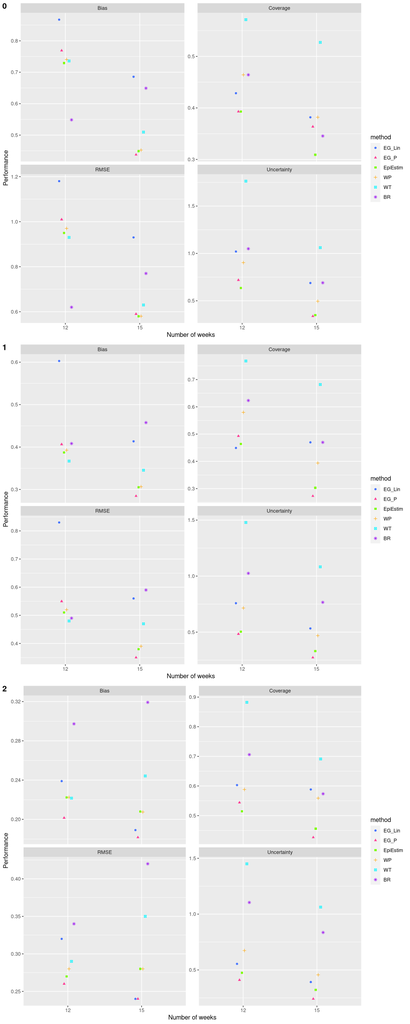

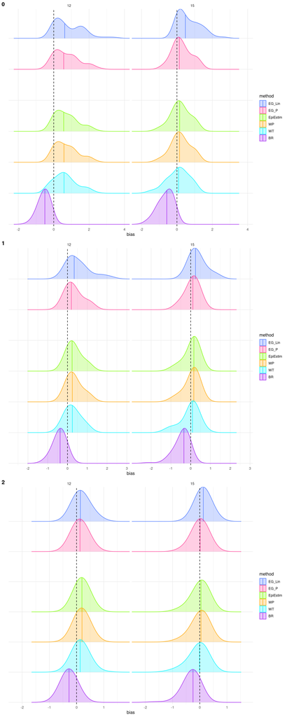

### Negative Binomial

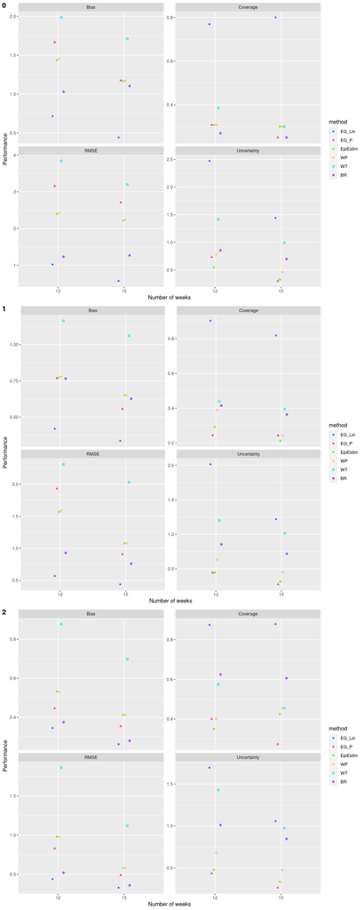

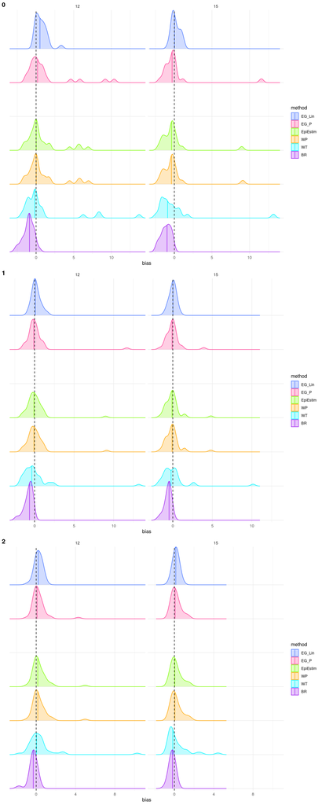